# What happens when we drop samples from a piano note?

A real sampled **A6 piano note**, not a single sine wave. We compare a 48 kHz working input with two 8 kHz outputs. The original three-tone experiment remains unchanged.

Source: Lawrence Fritts, University of Iowa Musical Instrument Samples, distributed as `39221__Piano.ff.A6.wav` in Pimoroni's Piano-HAT collection. See the bundled source license and attribution. The source is stereo PCM16 at 44.1 kHz; mono conversion and filtered resampling prepare the 48 kHz input. No extra tones are added.

```python
%matplotlib inline
from pathlib import Path
import hashlib, json, wave, math
import numpy as np
import matplotlib.pyplot as plt
from scipy.signal import resample_poly, firwin
from IPython.display import Audio, display, Markdown

ROOT = next(p for base in [Path.cwd(), *Path.cwd().parents]
            for p in (base, base / "2_downsample")
            if (p / "code" / "02_piano_downsampling.ipynb").is_file())
INPUT, OUT = ROOT / "input", ROOT / "output"
OUT.mkdir(exist_ok=True)
FS, FACTOR, FS_OUT = 48000, 6, 8000
def read_wav(path):
    with wave.open(str(path), "rb") as f:
        assert f.getsampwidth() == 2 and f.getcomptype() == "NONE"
        rate, channels = f.getframerate(), f.getnchannels()
        data = np.frombuffer(f.readframes(f.getnframes()), dtype="<i2").copy()
    return rate, data.reshape(-1, channels).astype(float).mean(axis=1) / 32768
def save_wav(path, x, fs):
    assert np.max(np.abs(x)) < 1, "Clipping would invalidate comparison"
    pcm = np.rint(x * 32767).astype("<i2")
    with wave.open(str(path), "wb") as f:
        f.setparams((1, 2, fs, len(pcm), "NONE", "not compressed"))
        f.writeframes(pcm.tobytes())
    return read_wav(path)[1]
def listen(x, rate):
    display(Audio(x, rate=rate, normalize=False))
```

## 1. Listen to the input

A piano key has a fundamental plus harmonics, an attack and a decaying envelope. A6 is nominally 1760 Hz. Its upper harmonics can exceed the **new** 4 kHz Nyquist limit even though the fundamental does not.

The source conversion uses SciPy's `resample_poly`, which already includes an anti-alias filter. That preparation is distinct from the intentionally unsafe sample dropping below. A single shared gain leaves headroom; we never normalize each result independently.

```python
source_rate, source = read_wav(INPUT / "piano_A6_source.wav")
gcd = math.gcd(source_rate, FS)
prepared = resample_poly(source, FS // gcd, source_rate // gcd)
# Trim at most five samples so both branches have exactly equal durations.
prepared = prepared[:len(prepared) // FACTOR * FACTOR]
shared_gain = 0.8 / np.max(np.abs(prepared))
x = save_wav(INPUT / "piano_48khz.wav", prepared * shared_gain, FS)
print(f"Source: {source_rate} Hz; working input: {FS} Hz; duration: {len(x)/FS:.4f} s")
listen(x, FS)
```

```
Source: 44100 Hz; working input: 48000 Hz; duration: 1.0301 s
```

[interactive chart not shown]

## 2. Keep one sample, skip five

Play the retained samples at 8 kHz. Duration stays the same; this is **not** a slow-motion effect. Harmonics above 4 kHz can fold into the remaining band and alter the timbre. The size of the audible difference depends on this particular note, your playback device and your hearing.

$$ y[m] = x[6m] $$

```python
raw = save_wav(OUT / "piano_8khz_unfiltered.wav", x[::FACTOR], FS_OUT)
listen(raw, FS_OUT)
```

[interactive chart not shown]

## 3–4. Inspect the saved input and output

All FFTs read the saved WAV data. We use the same 0.05–0.55 s section and a Hann window because a decaying piano note is not a coherent stationary test tone. Spectra use a common dBFS scale, not separate peak normalization. The shaded region cannot be represented faithfully at 8 kHz.

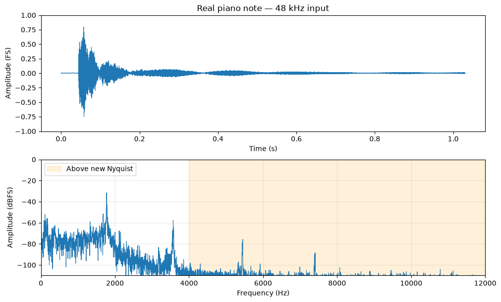

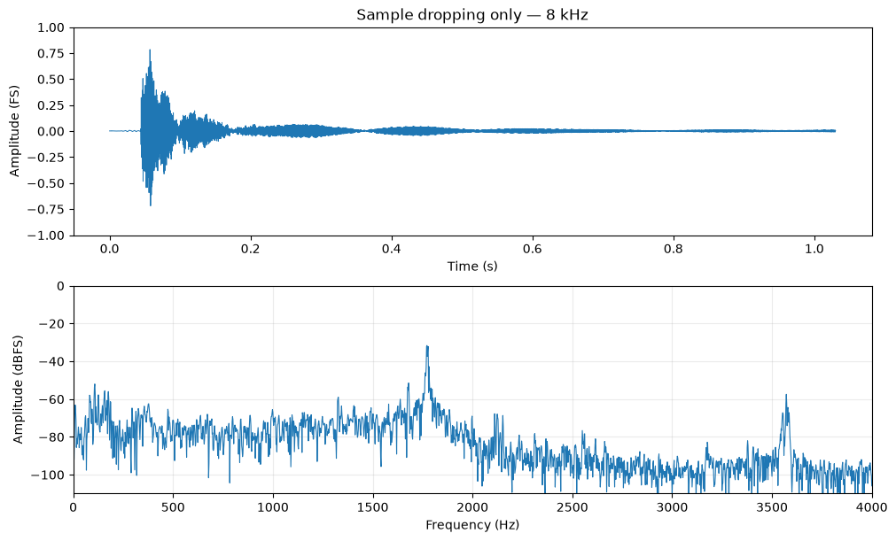

```python
def spectrum(samples, rate):
    segment = samples[int(.05 * rate):int(.55 * rate)]
    window = np.hanning(len(segment))
    amp = np.abs(np.fft.rfft(segment * window)) * 2 / window.sum()
    amp[0] /= 2
    if len(segment) % 2 == 0:
        amp[-1] /= 2
    return np.fft.rfftfreq(len(segment), 1 / rate), amp

def plot_audio(samples, rate, title, filename):
    freq, amp = spectrum(samples, rate)
    fig, axes = plt.subplots(2, 1, figsize=(10, 6), constrained_layout=True)
    time = np.arange(len(samples)) / rate
    axes[0].plot(time, samples, lw=.7)
    axes[0].set(xlabel="Time (s)", ylabel="Amplitude (FS)", ylim=(-1, 1), title=title)
    axes[1].plot(freq, 20 * np.log10(np.maximum(amp, 1e-8)), lw=.8)
    axes[1].set(xlabel="Frequency (Hz)", ylabel="Amplitude (dBFS)",
                xlim=(0, 12000 if rate == FS else 4000), ylim=(-110, 0))
    if rate == FS:
        axes[1].axvspan(4000, 12000, color="orange", alpha=.15, label="Above new Nyquist")
        axes[1].legend()
    axes[1].grid(alpha=.25)
    fig.savefig(OUT / filename, dpi=150)
    plt.show()
plot_audio(x, FS, "Real piano note — 48 kHz input", "piano_original.png")
plot_audio(raw, FS_OUT, "Sample dropping only — 8 kHz", "piano_unfiltered.png")
```

## 5. Low-pass first, then drop samples

A 513-tap Kaiser-window FIR, nominal cutoff 3.4 kHz, leaves a transition band before 4 kHz. We apply convolution **before** keeping every sixth sample. This removes much of the piano's original brightness, but avoids folding those upper harmonics into false lower frequencies.

For this offline comparison, centered convolution compensates the filter delay. A causal firmware implementation instead has 256/48000 seconds (5.33 ms) of delay and needs state across blocks. Boundary samples use zero padding; spectral verification excludes the boundaries.

[interactive chart not shown]

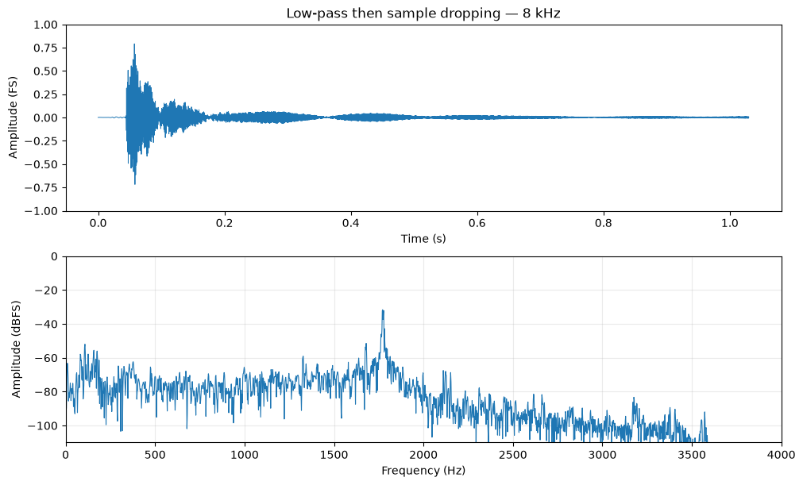

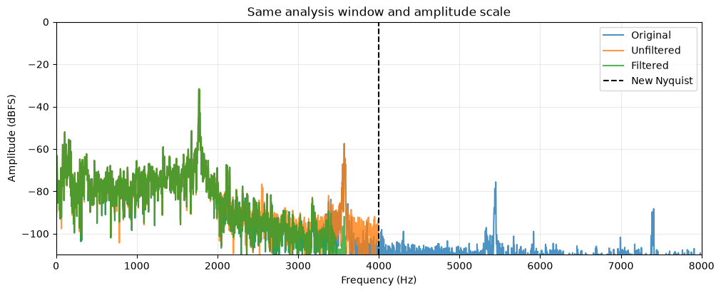

```python
h = firwin(513, 3400, fs=FS, window=("kaiser", 8.6))
low = np.convolve(x, h, mode="same")
filtered = save_wav(OUT / "piano_8khz_filtered.wav", low[::FACTOR], FS_OUT)
listen(filtered, FS_OUT)
plot_audio(filtered, FS_OUT, "Low-pass then sample dropping — 8 kHz", "piano_filtered.png")

fig, ax = plt.subplots(figsize=(10, 4), constrained_layout=True)
for samples, rate, label in [(x, FS, "Original"), (raw, FS_OUT, "Unfiltered"), (filtered, FS_OUT, "Filtered")]:
    f, a = spectrum(samples, rate)
    ax.plot(f, 20*np.log10(np.maximum(a, 1e-8)), label=label, alpha=.8)
ax.set(xlim=(0, 8000), ylim=(-110, 0), xlabel="Frequency (Hz)", ylabel="Amplitude (dBFS)",
       title="Same analysis window and amplitude scale")
ax.axvline(4000, color="black", ls="--", label="New Nyquist")
ax.legend()
ax.grid(alpha=.25)
fig.savefig(OUT / "piano_comparison.png", dpi=150)
plt.show()
```

## 6. Measure before drawing a conclusion

We measure windowed spectral energy above 4 kHz, relative to the total, and its reduction **before** decimation. This is a bandwidth-risk indicator, not a guarantee of audibility. It is not the same metric as the isolated 1 kHz alias in our three-tone experiment.

We also report the most prominent out-of-band spectral peak and its predicted folded frequency. Real piano harmonics are slightly inharmonic; folded components can overlap existing harmonics. A low-rate FFT alone cannot uniquely recover their original frequencies.

```python
f, a = spectrum(x, FS)
_, low_a = spectrum(low, FS)
mask = f > FS_OUT / 2
energy_fraction = float(np.sum(a[mask]**2) / np.sum(a**2))
suppression = float(10*np.log10(np.sum(a[mask]**2) / np.sum(low_a[mask]**2)))
peak = float(f[np.flatnonzero(mask)[np.argmax(a[mask])]])
folded = float(abs((peak + FS_OUT/2) % FS_OUT - FS_OUT/2))
fundamental_mask = (f > 1600) & (f < 1900)
fundamental = float(f[np.flatnonzero(fundamental_mask)[np.argmax(a[fundamental_mask])]])
assert abs(fundamental - 1760) < 80, "Check the sample's advertised note"
assert energy_fraction > 1e-5, "No substantial out-of-band content to demonstrate"
assert suppression > 40
for name, rate in [("piano_48khz.wav", FS)]:
    assert read_wav(INPUT / name)[0] == rate
for name in ("piano_8khz_unfiltered.wav", "piano_8khz_filtered.wav"):
    assert read_wav(OUT / name)[0] == FS_OUT
assert len(raw) == len(filtered) and len(x) == FACTOR * len(raw)
assert all(np.max(np.abs(v)) < .999 for v in (x, raw, filtered))
# In-band note survives both branches; no per-output normalization.
for v in (raw, filtered):
    vf, va = spectrum(v, FS_OUT)
    band = (vf > 1600) & (vf < 1900)
    assert abs(vf[np.flatnonzero(band)[np.argmax(va[band])]] - fundamental) < 10
measurements = dict(source_rate_hz=source_rate, input_rate_hz=FS, output_rate_hz=FS_OUT,
    duration_s=len(x)/FS, shared_gain=float(shared_gain), fundamental_hz=fundamental,
    out_of_band_energy_percent=100*energy_fraction, pre_decimation_reduction_db=suppression,
    strongest_out_of_band_hz=peak, predicted_folded_hz=folded,
    output_difference_rms_fs=float(np.sqrt(np.mean((raw-filtered)**2))),
    fir_taps=len(h), cutoff_hz=3400, causal_delay_ms=256/FS*1000)
artifacts = {"source_audio": "input/piano_A6_source.wav",
 "source_license": "input/piano_source_LICENSE.txt",
 "attribution": "input/piano_attribution.md",
 "original_audio": "input/piano_48khz.wav",
 "unfiltered_audio": "output/piano_8khz_unfiltered.wav",
 "filtered_audio": "output/piano_8khz_filtered.wav",
 "original_plot": "output/piano_original.png",
 "unfiltered_plot": "output/piano_unfiltered.png",
 "filtered_plot": "output/piano_filtered.png",
 "comparison_plot": "output/piano_comparison.png"}
notebook = json.loads((ROOT/"code"/"02_piano_downsampling.ipynb").read_text(encoding="utf-8"))
code_source = "\n".join("".join(c["source"]) for c in notebook["cells"] if c["cell_type"] == "code")
manifest = dict(verified=True, measurements=measurements,
    source_code_sha256=hashlib.sha256(code_source.encode()).hexdigest(),
    artifacts={k: dict(path=p, sha256=hashlib.sha256((ROOT/p).read_bytes()).hexdigest())
               for k,p in artifacts.items()})
(OUT/"piano_results.json").write_text(json.dumps(manifest, indent=2), encoding="utf-8")
display(Markdown(f"""**Verified:** {100*energy_fraction:.2f}% of the analyzed input spectral energy
is above 4 kHz. The filter reduces that energy by **{suppression:.2f} dB** before sample dropping.
A prominent {peak:.0f} Hz component folds to {folded:.0f} Hz.
The fundamental is measured near {fundamental:.0f} Hz; duration stays {len(x)/FS:.4f} s."""))
```

**Verified:** 0.01% of the analyzed input spectral energy is above 4 kHz. The filter reduces that energy by **110.40 dB** before sample dropping. A prominent 5450 Hz component folds to 2550 Hz. The fundamental is measured near 1772 Hz; duration stays 1.0301 s.

## Future improvements: detecting risky bandwidth

- Measure the energy above the **target** Nyquist limit on the high-rate input, as a first prototype.
- Extend to short-time FFT/averaged PSD so the attack and decay are evaluated separately; a single long window can hide bursts.
- Test notes at different pitches, velocities and recording noise floors. Choose a threshold with missed-event and false-alarm costs in mind.
- Measure CPU cost and stream the FIR with persistent state on an MCU. Compare an efficient polyphase implementation.
- Detection does not replace anti-alias filtering. Once only 8 kHz samples remain, their FFT cannot tell which components were originally above 4 kHz.

Listening is subjective. Filtering changes bandwidth and timbre intentionally; do not label every audible difference as aliasing. No ultrasonic test tone is injected into this piano recording.